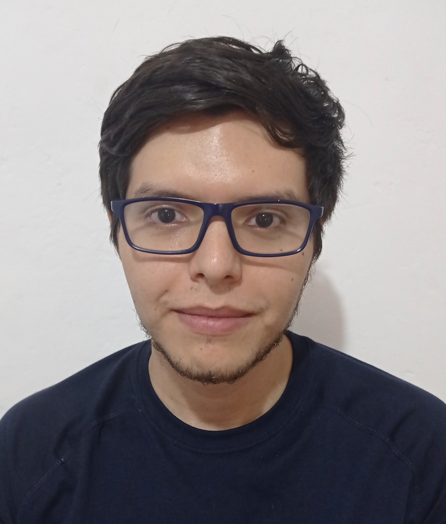

# Pablo Yamild Rosiles Loeza

**For english version go to the bottom

## Biografía

Profesional con experiencia en gestión de equipos, comunicación científica, transferencia de tecnología y genómica. Miembro de la “RNA society”. Pertenecí al programa Talentum universidad y Shaping Horizons, organizado por el CIDE y la Universidad de Cambridge, respectivamente. Actualmente curso el programa de maestría en biotecnología de plantas en el Cinvestav donde me desempeño en el laboratorio de RNA regulatorio analizando marcas de cromatina en RNAs largos no codificantes utilizando Python y R.

## Educación

##### Maestría en Ciencias, especialidad en biotecnología de plantas | Agosto 2020 - Actualidad

**Cinvestav Unidad Irapuato** | Irapuato, Gto *Laboratorio de RNA regulatorio*

##### Ingeniería en biotecnología | Agosto 2015 - Julio 2019

**Instituto Politécnico Nacional** | Silao, Gto. *Unidad Profesional Interdisciplinaria de Ingeniería Campus Guanajuato* Cédula Profesional: 12064286

## Experiencia

- **Colaborador principal** | Biolaunch | Enero 2020 - Actualidad
- **Coordinador del concurso de emprendimiento** | Biolaunch | Enero 2019 - Diciembre 2019
- **Colaborador en el Taller de Emprendimiento** | Congreso de la Sociedad Mexicana de Biotecnología y Bioingeniería | Julio 2019
- **Co-coordinador de políticas públicas** | Allbiotech | Enero 2019 - Junio 2019
- **Tesista de licenciatura** | Laboratorio de transformación genética de plantas CINVESTAV-Irapuato | Diciembre 2017 - Junio 2019
- **Colaborador** | Clubes de Ciencia México | Agosto de 2018
- **Equipo de logística** | Allbiotech | Marzo de 2018 - Diciembre de 2018

## Publicaciones

- Herrera-Isidron, L., Valencia-Lozano, E., **Rosiles-Loeza, P. Y.**, Robles-Hernández, M. G., Napsuciale-Heredia, A., & Cabrera-Ponce, J. L. (2021). Gene Expression Analysis of Microtubers of Potato Solanum tuberosum L. Induced in Cytokinin Containing Medium and Osmotic Stress. Plants, 10(5), 876. https://doi.org/10.3390/plants10050876
- Ozment, E., Tamvacakis, A. N., Zhou, J., **Rosiles-Loeza, P. Y.**, Escobar-Hernandez, E. E., Fernandez-Valverde, S. L., & Nakanishi, N. (2021). Cnidarian hair cell development illuminates an ancient role for the class IV POU transcription factor in defining mechanoreceptor identity. Elife, 10, e74336. DOI: 10.7554/eLife.74336

## Lenguajes extranjeros

- **Inglés** | TOEFL iBT 100
- **Alemán** | Nivel B1

## Cursos y diplomados

- **Science diplomacy** | The bridge biofoundry & Alliance for science | Septiembre 2021
- **Análisis de datos transcriptómicos de sigle cell (scRNA-seq) con R y bioconductor** | NNB-CCG & CDSB | Agosto 2021
- **Recomendaciones para un retorno seguro al trabajo ante COVID-19** | IMSS | Agosto 2021
- **Plagio y citación** | Cinvestav | Mayo 2021
- **Covid-19 y estimación de parámetros en ecuaciones diferenciales ordinarias** | UNAM |Julio 2020
- **Introducción a la bioinformática con enfoque en bioeconomía** | ISCB Student Council | Octubre 2019
- **Shaping Horizons: Summit and action programme** | University of Cambridge | Mayo – Octubre 2019
- **Talentum Universidad** | CIDE | Junio - Diciembre 2019
- **Introducción a teorías feministas** | UAbierta de la Universidad de Chile | Marzo - Abril 2019
- **Escuela de verano en Bioinformática** | UNAM Juriquilla | Verano 2017
- **Verano de investigación científica** | Academia Mexicana de Ciencias & UNAM | Verano 2016

## Participación en congresos y reconocimientos

- Colaborador en Plants & Python | Curso de Fundamentos de la Biología Vegetal Computacional en la Universidad Estatal de Michigan | [Consulta la página aquí](https://plantsandpython.github.io/PlantsAndPython/) | 2021
- Colaborador en talent republic | [Consulta perfil aquí](https://www.talent-republic.tv/author/pablo-yamild-r/)
- Torneo Virtual México debate | Torneo organizado por Instituto Nacional Electoral y la Asociación Mexicana de Debate | 2020
- Análisis de la señalización de citocininas en la respuesta a estímulos ambientales para la tuberización de papa (*Solanum tuberosum L.*) en cultivo *in vitro* | Cartel en Foro PIFI | Agosto 2019
- Mejoras en un biorreactor de inmersión temporal electroneumático para el cultivo in vitro de tejidos vegetales | Cartel en **XVI Encuentro: Participación de la mujer en la ciencia** | Mayo 2019
- ¿Por qué no hay científicas? | Ponencia en el marco del día internacional de la mujer y la niña en la ciencia: **Allbiotech** | Febrero 2019
- Renou. Renovando la vida | Proyecto presentado en **Emprendedores en Bionegocios 2017** organizado por AGROBIOTEG | Junio 2017
- Crecimiento de cristales fosfatos de calcio en fibras de ácido poliláctico (PLA) y cloruro de calcio | Cartel en **XXIV Encuentro Nacional y XV Iberoamericano de Investigación en Odontología** | Noviembre 2016

# Resume in english

## Bio

Professional with experience in team management, scientific communication, technology transfer and genomics. Member of the RNA society. I belonged to the Talentum University programme and Shaping Horizons, organised by the CIDE and the University of Cambridge, respectively. I am currently studying for a master’s degree in plant biotechnology at Cinvestav where I work in the regulatory RNA laboratory analysing chromatin marks in long non-coding RNAs using Python and R.

## Education

##### Master of Science, specialization in plant biotechnology | August 2020 - Present

**Cinvestav Unidad Irapuato** | Irapuato, Gto.

*Regulatory RNA laboratory*

##### Biotechnology Engineering | August 2015 - July 2019

**Instituto Politécnico Nacional** | Silao, Gto.

*Unidad Profesional Interdisciplinaria de Ingeniería Campus Guanajuato* Professional License: 12064286

## Experience

- **Principal Collaborator** | Biolaunch | January 2020 - Current
- **Coordinator of the entrepreneurship contest** | Biolaunch | January 2019 - December 2019
- **Collaborator in the Entrepreneurship Workshop** | Congress of the Mexican Society of Biotechnology and Bioengineering | July 2019
- **Public policy coordinator** | Allbiotech | January 2019 - June 2019
- **Undergraduate thesis student** | Laboratory of Plant Genetic Transformation CINVESTAV-Irapuato | December 2017 - June 2019
- **Collaborator** | Science Club México | August 2018
- **Logistics team** | Allbiotech | March 2018 - December 2018

## Publications

- Herrera-Isidron, L., Valencia-Lozano, E., **Rosiles-Loeza, P. Y.**, Robles-Hernández, M. G., Napsuciale-Heredia, A., & Cabrera-Ponce, J. L. (2021). Gene Expression Analysis of Microtubers of Potato Solanum tuberosum L. Induced in Cytokinin Containing Medium and Osmotic Stress. Plants, 10(5), 876. https://doi.org/10.3390/plants10050876.
- Ozment, E., Tamvacakis, A. N., Zhou, J., **Rosiles-Loeza, P. Y.**, Escobar-Hernandez, E. E., Fernandez-Valverde, S. L., & Nakanishi, N. (2021). Cnidarian hair cell development illuminates an ancient role for the class IV POU transcription factor in defining mechanoreceptor identity. Elife, 10, e74336. DOI: 10.7554/eLife.74336

## Foreign languages

- **English** | TOEFL iBT 100
- **German** | Level B1

## Courses and diplomas

- **Science diplomacy** | The bridge biofoundry & Alliance for science | September 2021
- **Analysis of sigle cell transcriptomic data (scRNA-seq) with R and bioconductor** | NNB-CCG & CDSB | August 2021
- **Recommendations for a safe return to work before COVID-19** | IMSS | August 2021
- **Plagiarism and citation** | Cinvestav | May 2021
- **COVID-19 and parameter estimation in ordinary differential equations** | UNAM | July 2020
- **Introduction to bioinformatics with a focus on bioeconomics** | ISCB Student Council | October 2019
- **Shaping Horizons: Summit and action programme** | Cambridge University | May - October 2019
- **Talentum University** | CIDE | June - December 2019
- **Introduction to Feminist Theories** | UAbierta de la Universidad de Chile | March - April 2019
- **Summer School in Bioinformatics** | UNAM Juriquilla | Summer 2017
- **Summer of scientific research** | Academia Mexicana de Ciencias & UNAM | Summer 2016

## Participation in congresses and acknowledgements

- Collaborator in Plants & Python Course | Foundation in Computational Plant Science course at Michigan State University | [Consult the page here](https://plantsandpython.github.io/PlantsAndPython/) | 2021
- Contributor to talent republic | [See profile here](https://www.talent-republic.tv/author/pablo-yamild-r/)
- Virtual Mexico Debate Tournament | Tournament organized by the National Electoral Institute and the Mexican Debate Association | 2020
- Analysis of cytokinin signaling in response to environmental stimuli for potato tuberization (*Solanum tuberosum L.*) in *in vitro* culture | Poster in PIFI Forum | August 2019
- Improvements in an electro-pneumatic temporary immersion bioreactor for in vitro plant tissue culture | Poster at **XVI Meeting: Participation of women in science** | May 2019
- Why are there no women scientists? | Presentation in the framework of the International Day of Women and Girls in Science: **Allbiotech** | February 2019
- Renou: Renewing life | Project presented at **Entrepreneurs in Biobusiness 2017** organized by AGROBIOTEG | June 2017.
- Growth of calcium phosphate crystals in polylactic acid (PLA) and calcium chloride fibers | Poster at **XXIV National and XV Iberoamerican Meeting of Research in Dentistry** | November 2016